# Summarizing and Visualizing Data II

# Revisiting the Lab

## Question 4: What type of sampling

The sampling process was:

1. 50 days chosen randomly from a 10 month period
2. In each chosen day, all parole cases observed

This is **cluster sampling**: The days are the clusters.

## Question 6, Part 1: An Experiment

**A useful principle to remember**

The object being assigned to treatment and control groups must be the same object that the outcome is measured on.

- Many answers suggested randomizing judges to different conditions
- But the outcome (accept or reject parole request) is measured on *requests/rulings*
- The treatment is whether the request is after a meal break
- So, we could randomize the requests to first or second half of a session

## Question 6, Part 2: Other Explanations

No temporal pattern with other variables?

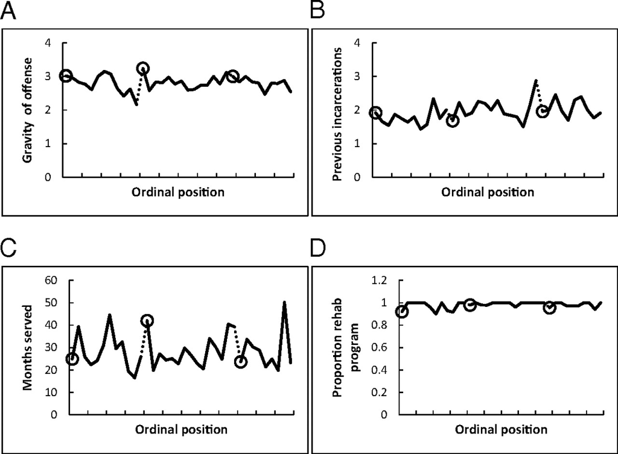

## A Follow-Up

From a reply, “Overlooked factors in the analysis of parole decisions”:

> We also interviewed three attorneys, a parole panel judge, and five personnel at Israeli Prison Services and Court Management, learning that case ordering is not random and that several factors contribute to the downward trend in prisoner success between meal breaks. The most important is that the board tries to complete all cases from one prison before it takes a break and to start with another prison after the break. Within each session, unrepresented prisoners usually go last and are less likely to be granted parole than prisoners with attorneys.

(Weinshall-Margel and Shapard 2011)

# Summarizing Data

## Numerical Summaries

A **numerical summary** is one number or a few numbers that concisey summarize some features of interest in a potentially large set of numeric data.

Numerical summaries are especially useful for *comparison*.

# Measures of Center

## Measures of Center

A measure of center tries to answer the question: “What is the most typical value for this dataset?”

If we compare measures of center in two datasets, we are asking: “Which of these things is larger, typically?”

## The Mean

**Definition: The Mean**

If a dataset with $n$ cases contains a numeric variable $x$ with values $x_1, x_2,\ldots, x_n$, then then mean of $x$ in this dataset is:
$$\overline{x} = \frac{1}{n}\sum_{i=1}^n x_i$$

- The mean is a “compromise” between all the values in the dataset
- The mean is the most commonly reported measure of center

## The Mean

**Sensitivity of the Mean**

The mean can be highly influenced by a few extreme values in a dataset.

What is the mean of ten numbers if:

- They are all 1?
- Nine are 1 and one is 11?
- Nine are 1 and one is 991?

If the mean is like a compromise between all the values, think about how hard it is to find a compromise among many people when one person is very loud and has a very strong opinion.

## The Median

**Definition: The Median**

If a dataset with $n$ cases contains a numeric variable $x$ with values $x_1, x_2,\ldots, x_n$, then then median of $x$ in this dataset is a value $\mathrm{med}(x)$ such that half of the data points are less than or equal to it and the other half is greater than or equal to it. Specifically:

- If $n$ is odd, the median is the middle point after ordering the data.
- If $n$ is even, there is no one middle point, so we just take the mean of the two points closest to the middle.
- The median is more representative of a typical member of the dataset
- If our dataset consists of people, the median is closer to the “average person”

## The Median

What is the median of ten numbers if:

- They are all 1?
- Nine are 1 and one is 11?
- Nine are 1 and one is 991?

## Median and Mean

**Discussion Question**

If you were interested in comparing living standards between two countries, would you prefer to compare the mean income or the median income?

If you wanted to estimate the total revenue generated by a tax for funding a government program, would you prefer to estimate the mean tax revenue per household, or the median?

## Median and Mean

**Choosing Summaries**

Whether you should prefer the mean or median depends not only the data, but also on the question you’re trying to answer. This extends to all choices of summary and visualization.

**Evaluating Summaries**

When reading statistical summaries produced by someone else, ask how the choice of summary relates to the question they’re asking or the point they’re trying to make. Be aware that summaries are sometimes chosen for convenience to make an argument appear stronger, even when a different summary would be more appropriate.

## Intermission: Why Summarize?

**Discussion Question**

If you have a numerical variable $x$, when would prefer to report a mean/median, and when would you prefer to construct a histogram?

# Measures of Spread

## Measures of Spread

A measure of spread answers the question: “How much does this quantity vary across different cases?”

If we compare measures of spread in two datasets, we are asking: “In which dataset are the values of this quantity more consistent and predictable?”

## Spread and Deviation

To quantify spread, we can measure how far data points are from the typical value.

Suppose dataset with $n$ cases contains a numeric variable $x$ with values $x_1, x_2,\ldots, x_n$.

**Definition: Deviation**

The **deviation** of point $x_i$ is defined as $x_i - \overline{x}$.

## Spread and Deviation

We usually only care how far values are from typical, not whether they’re larger of smaller than the typical value.

E.g. points with deviations $-10$ and $10$ are equally far from the mean.

In order to “forget” the sign, we can take a squared deviation $(x_i - \overline{x})^2$.

But this messes up our units: if $x_i$ is a number in inches, the squared deviation is in inches squared… we will return to this in a moment

## The Standard Deviation

**Definition: Standard Deviation**

The **standard deviation** of a variable is just the square root of the mean of the squared deviations:
$$s_x = \sqrt{\frac{1}{n}\sum_{i=1}^n (x_i-\overline{x})^2}.$$

- Answers the question “Among all data points, what is a typical deviation from the mean?”
- Taking square root fixes the units problem: If $x_i$ are numbers in inches, $s_x$ is also a number in inches.

## Sensitivity of the Standard Deviation

**Sensitivity of the SD**

Because the SD involves a mean, it inherits the mean’s sensitivity to extremes. Specifically, the standard deviation can be strongly influenced by a few data points with especially large deviations from the mean.

What is the standard deviation of ten numbers if:

- They are all 0?
- Nine are 0 and one is 10?
- Nine are 0 and one is 1000?

## A Note About Variance

The variance is just
$$s_x^2 = \frac{1}{n}\sum_{i=1}^n (x_i-\overline{x})^2.$$

Why do we give this quantity it’s own name?

- Because variance is just a mean, it’s easier to work with mathematically
- The square root in the standard deviation makes it less nice to manipulate
- But the standard deviation is much nicer for interpretation
- We will mostly work with the standard deviation throughout this course

## A Missing Piece

The standard deviation “goes with” the mean:

- Mean used as measure of center for calculating SD
- SD is sensitive to extremes like the mean

Is there a measure of spread that “goes with” the median?

Yes, but we need to take a detour to get there.

# Quantiles

## Quantiles, Roughly

**Rough Definition: Quantiles**

Let a dataset with $n$ cases contain a variable $x$. Let $p$ be a number between 0 and 1. The $p$-quantile of $x$ is the point $x_{(p)}$ such that $100p\%$ of the $x_i$ are less than or equal to $x_{(p)}$, and $100(1-p)\%$ are greater than or equal to $x_{(p)}$.

**Discussion Question**

We have already seen one quantile by another name. Can you name the concept we’ve learned that’s a quantile, and identify the value of $p$ for this quantile?

## A Problem with the Rough Definition

Take $p=0.25$. It can happen that there is no point in the data that splits the data into groups of size 25% and 75% of the total.

**Discussion Question**

Consider the variable $x=1,2,3,4$. What should the 0.25-quantile be?

## Quantiles, More Precisely

**Definition: Quantiles**

Let a dataset with $n$ cases contain a variable $x$. Let $p$ be a number between 0 and 1. Assume that the values of $x$ are sorted in increasing order. The $p$-quantile of $x$ is defined as follows:

1. If $np+(1/2)$ is a whole number, $x_{(p)} = x_{np+(1/2)}$.
2. If $np+(1/2)$ is not a whole number, let $l$ and $g$ be the closest whole numbers less than and greater than $np+(1/2)$, respectively. Then
   $$x_{(p)} = \frac{x_l + x_g}{2}.$$

## Quantile Examples

**Quantiles**

1. If $np+(1/2)$ is a whole number, $x_{(p)} = x_{np+(1/2)}$.
2. If $np+(1/2)$ is not a whole number, let $l$ and $g$ be the closest whole numbers less than and greater than $np+(1/2)$, respectively. Then
   $$x_{(p)} = \frac{x_l + x_g}{2}.$$

**Examples:** Using the definition,

1. find the 0.5-quantile of $x=1,2,3$
2. find the 0.25-quantile of $x=1,2,3,4$
3. find the (1/3)-quantile of $x=1,2,3,4$

## Quantiles, The Big Picture

**Important**

**Do not let the esoteric definition of quantiles intimidate you!**

The $x_{(p)}$ quantile:

1. Divides the data into $100p\%$ of the data points less than $x_{(p)}$ and $100(1-p)\%$ greater than $x_{(p)}$…
2. … as closely as possible, though this might be only roughly true in small datasets.

## Quantiles, The Big Picture

**What you need to know:**

1. The rough definition is the most important thing to understand
2. If you need to use the exact definition to find a quantile, I will give it to you (e.g. on a formula sheet)
3. The point of the formal definition is to understand that we can translate the “roughly” in the rough definition into a specific approximation.

## When Will I Ever Use This in Real Life…?

**Discussion Question**

Can you think of a “real life” example in which quantiles come up?

Hint: You have probably already encountered quantiles in your life somewhere.

# Quartiles

## Quartiles

**Note**

The three **quartiles** $Q_1$, $Q_2$, and $Q_3$ are the numbers that divide a variable into quarters, specifically:
$$Q_1 = x_{(0.25)}, \quad Q_{2} = x_{(0.5)},\quad Q_3 = x_{(0.75)}.$$

**Notes:**

- The second quartile is just the median
- We only define quartiles for convenience. Its easier to say “first quartile” than “0.25-quantile”.

## Putting Quantiles to Work: The Interquartile Range

We are finally ready to define the second measure of spread

**Definition: Interquartile Range**

The **interquartile range** is just the distance between the first and third quartiles, i.e.:
$$\mathrm{IQR} = Q_3 - Q_1.$$

The IQR “goes with” the median in two ways:

1. It is defined with quantiles, like the median
2. It is *not* sensitive to extremes, like the median

## The Insensitivity of the IQR

**Discussion Question**

Can you explain in words *why* the IQR is insensitive to extreme values?

Hint: The IQR is $Q_3 - Q_1$. One way to explain this is to explain why $Q_1$ and $Q_3$ are insensitive to extremes.

## Putting Quantiles to Work: Box Plots

A box plot is a funny visualization that is useful for quickly summarizing a variable…

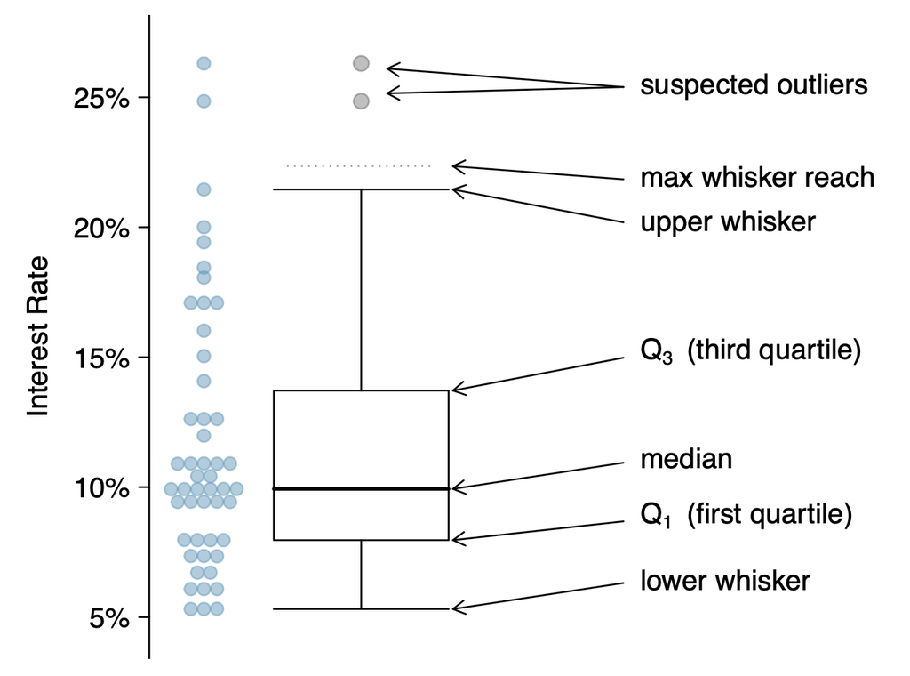

## Box Plots

**Definition: Box Plot**

1. Draw a rectangle (**box**) with edges at the first and third quartiles
2. Inside the rectangle, draw a line at the median (second quartile)
3. Draw a line (**whisker**) out from the top of the rectangle, stopping when you reach the largest value that is within $1.5\times\mathrm{IQR}$ of $Q_3$.
4. Draw a line (**whisker**) out from the bottom of the rectangle, stopping when you reach the smallest value that is within $1.5\times\mathrm{IQR}$ of $Q_1$.
5. If you *not* reach the maximum or minimum of the data in steps 3 and 4, draw in any points you didn’t reach with dots. These are called **outliers**

## References

Weinshall-Margel, Keren, and John Shapard. 2011. “Overlooked Factors in the Analysis of Parole Decisions.” *Proceedings of the National Academy of Sciences* 108 (42): E833–33. https://doi.org/10.1073/pnas.1110910108.